# Herbivory_experiment_0824

# **5.1 AT 50m scale**

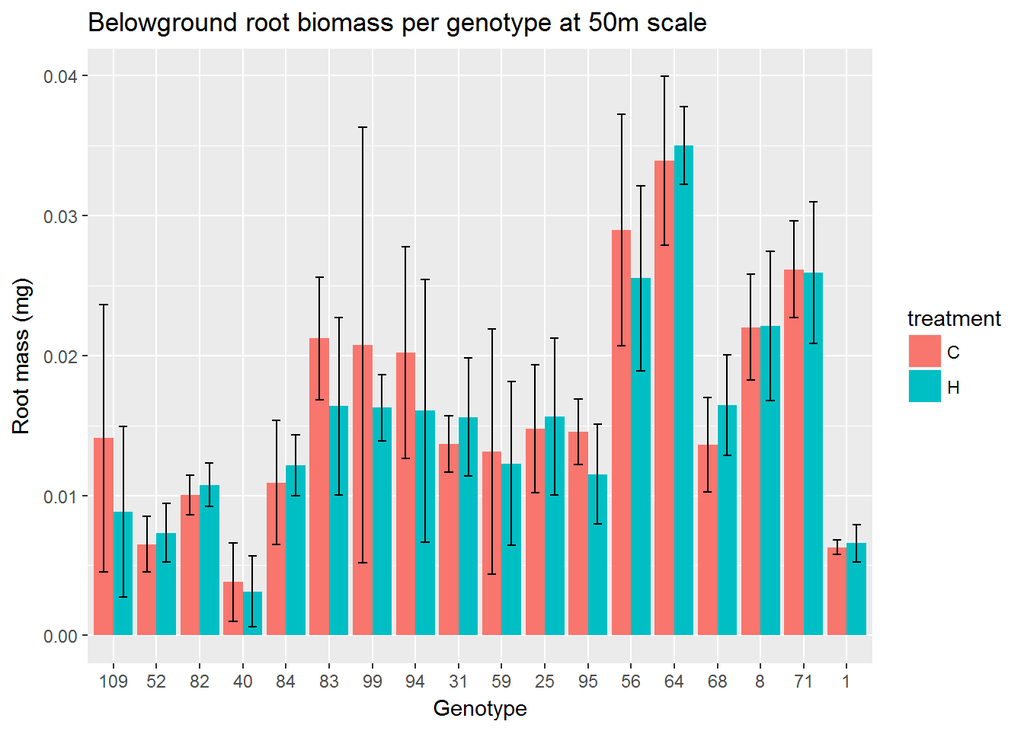

```r
# at 50m scale

## order genotypes by specifying urbanisation at 50m scale
mass.geno.BU <- mass.geno.BU %>%
  arrange(d50) %>%
  mutate(genotype = factor(genotype, unique(genotype)))


## plot
p.BG.50 <- ggplot(mass.geno.BU, aes(x=genotype, y=mBG, fill=treatment)) +
  geom_bar(stat = "identity",
           position = position_dodge()) +
  geom_errorbar(aes(ymin=mBG-sd.BG, ymax=mBG+sd.BG), width=.4,
                position = position_dodge(.9)) +
  labs(title = "Belowground root biomass per genotype at 50m scale", x = "Genotype", y = "Root mass (mg)")

p.AG.50 <- ggplot(mass.geno.BU, aes(x=genotype, y=mAG, fill=treatment)) +
  geom_bar(stat = "identity",
           position = position_dodge()) +
  geom_errorbar(aes(ymin=mAG-sd.AG, ymax=mAG+sd.AG), width=.4,
                position = position_dodge(.9)) +
  labs(title = "Aboveground shoot biomass per genotype at 50m scale", x = "Genotype", y = "Shoot mass (mg)")

p.rs.50 <- ggplot(mass.geno.BU, aes(x=genotype, y=mratio, fill=treatment)) +
  geom_bar(stat = "identity",
           position = position_dodge()) +
  geom_errorbar(aes(ymin=mratio-sd.ratio, ymax=mratio+sd.ratio), width=.4,
                position = position_dodge(.9)) +
  labs(title = "Ratio of root and shoot per genotype at 50m scale", x = "Genotype", y = "Root/shoot")

p.BG.50
```

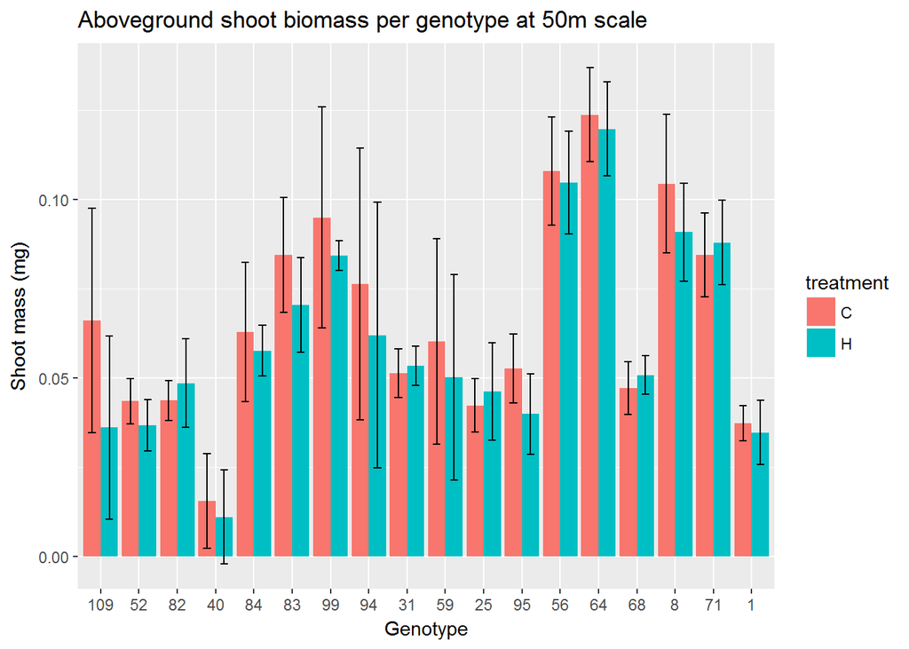

```r
p.AG.50
```

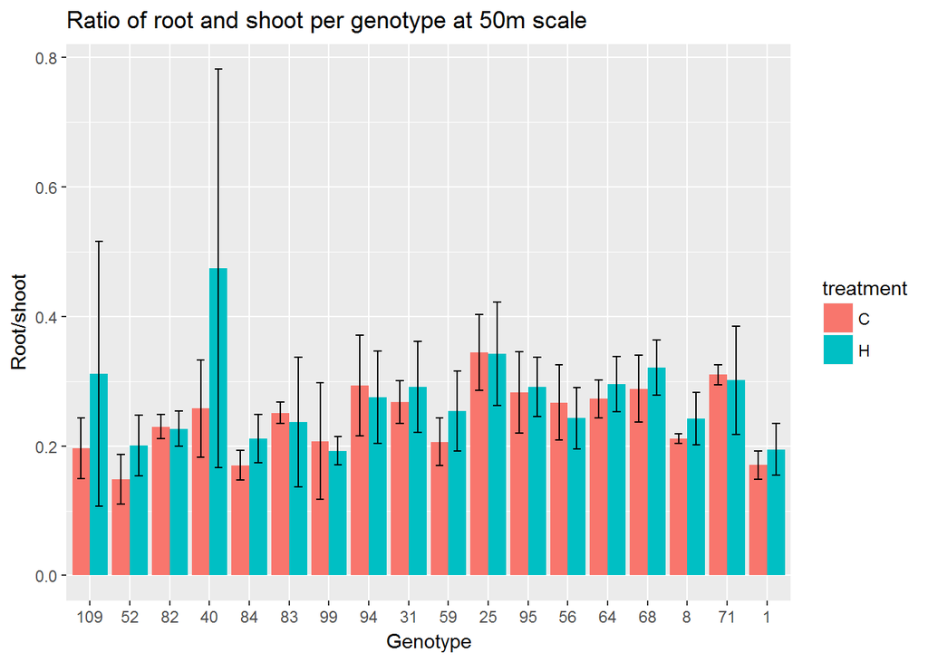

```r
p.rs.50
```

# **5.2 AT 100m scale**

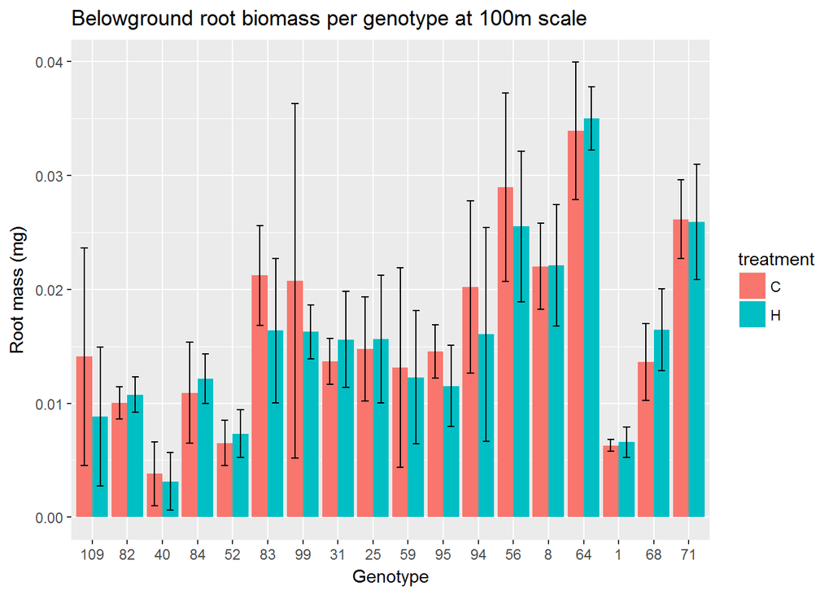

```r
## order genotypes by specifying urbanisation at 100m scale
mass.geno.BU <- mass.geno.BU %>%
  arrange(d100) %>%
  mutate(genotype = factor(genotype, unique(genotype)))

## plot
p.BG.100 <- ggplot(mass.geno.BU, aes(x=genotype, y=mBG, fill=treatment)) +
  geom_bar(stat = "identity",
           position = position_dodge()) +
  geom_errorbar(aes(ymin=mBG-sd.BG, ymax=mBG+sd.BG), width=.4,
                position = position_dodge(.9)) +
  labs(title = "Belowground root biomass per genotype at 100m scale", x = "Genotype", y = "Root mass (mg)")

p.AG.100 <- ggplot(mass.geno.BU, aes(x=genotype, y=mAG, fill=treatment)) +
  geom_bar(stat = "identity",
           position = position_dodge()) +
  geom_errorbar(aes(ymin=mAG-sd.AG, ymax=mAG+sd.AG), width=.4,
                position = position_dodge(.9)) +
  labs(title = "Aboveground shoot biomass per genotype at 100m scale", x = "Genotype", y = "Shoot mass (mg)")

p.rs.100 <- ggplot(mass.geno.BU, aes(x=genotype, y=mratio, fill=treatment)) +
  geom_bar(stat = "identity",
           position = position_dodge()) +
  geom_errorbar(aes(ymin=mratio-sd.ratio, ymax=mratio+sd.ratio), width=.4,
                position = position_dodge(.9)) +
  labs(title = "Ratio of root and shoot per genotype at 100m scale", x = "Genotype", y = "Root/shoot")

p.BG.100
```

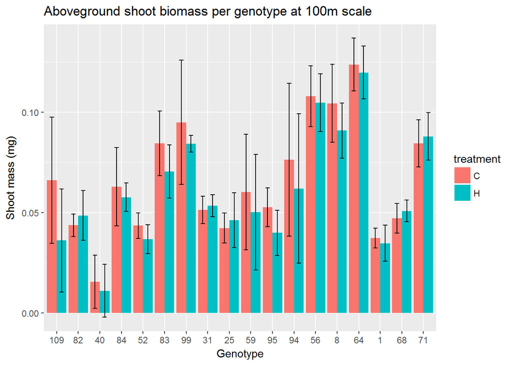

```r
p.AG.100
```

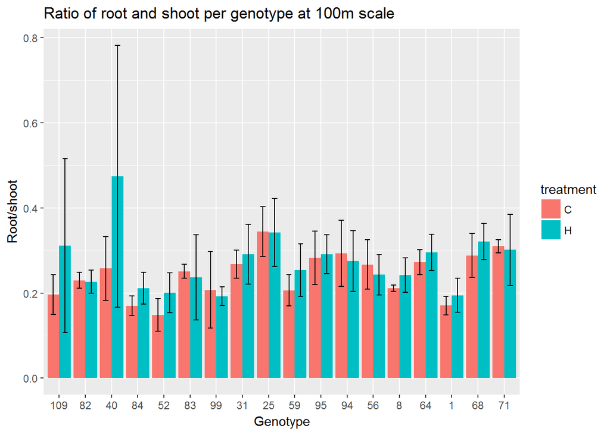

```r
p.rs.100
```

# **5.3 AT 200m scale**

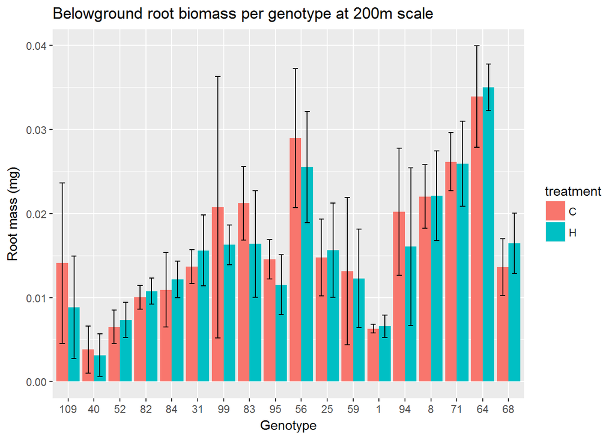

```r
## order genotypes by specifying urbanisation at 200m scale
mass.geno.BU <- mass.geno.BU %>%
  arrange(d200) %>%
  mutate(genotype = factor(genotype, unique(genotype)))
## plot
p.BG.200 <- ggplot(mass.geno.BU, aes(x=genotype, y=mBG, fill=treatment)) +
  geom_bar(stat = "identity",
           position = position_dodge()) +
  geom_errorbar(aes(ymin=mBG-sd.BG, ymax=mBG+sd.BG), width=.4,
                position = position_dodge(.9)) +
  labs(title = "Belowground root biomass per genotype at 200m scale", x = "Genotype", y = "Root mass (mg)")

p.AG.200 <- ggplot(mass.geno.BU, aes(x=genotype, y=mAG, fill=treatment)) +
  geom_bar(stat = "identity",
           position = position_dodge()) +
  geom_errorbar(aes(ymin=mAG-sd.AG, ymax=mAG+sd.AG), width=.4,
                position = position_dodge(.9)) +
  labs(title = "Aboveground shoot biomass per genotype at 200m scale", x = "Genotype", y = "Shoot mass (mg)")

p.rs.200 <- ggplot(mass.geno.BU, aes(x=genotype, y=mratio, fill=treatment)) +
  geom_bar(stat = "identity",
           position = position_dodge()) +
  geom_errorbar(aes(ymin=mratio-sd.ratio, ymax=mratio+sd.ratio), width=.4,
                position = position_dodge(.9)) +
  labs(title = "Ratio of root and shoot per genotype at 200m scale", x = "Genotype", y = "Root/shoot")

p.BG.200
```

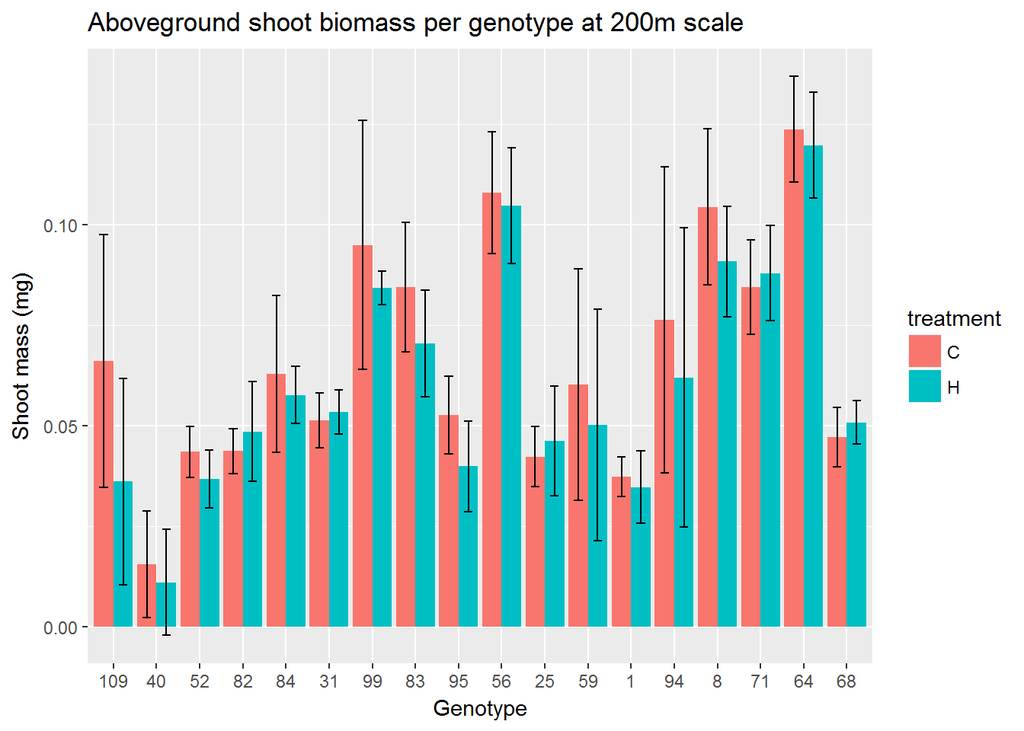

```r
p.AG.200
```

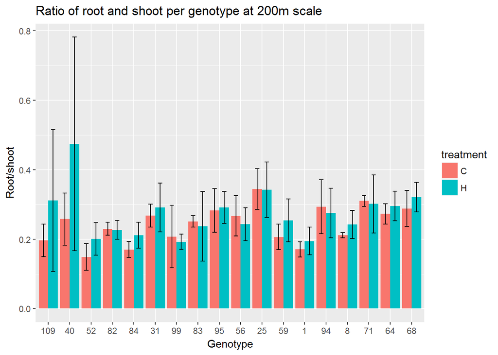

```r
p.rs.200
```

# **5.4 AT 400m scale**

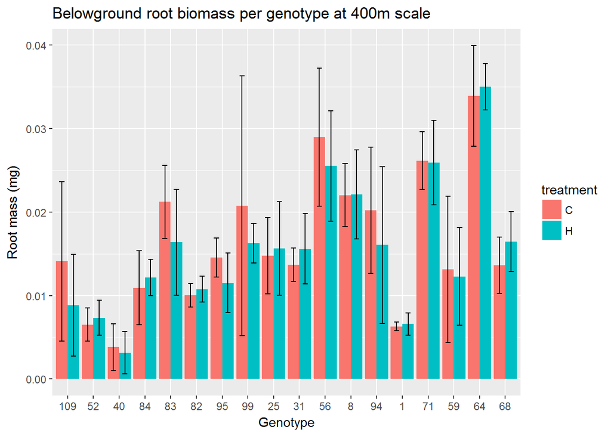

```r
## order genotypes by specifying urbanisation at 400m scale
mass.geno.BU <- mass.geno.BU %>%
  arrange(d400) %>%
  mutate(genotype = factor(genotype, unique(genotype)))
## plot
p.BG.400 <- ggplot(mass.geno.BU, aes(x=genotype, y=mBG, fill=treatment)) +
  geom_bar(stat = "identity",
           position = position_dodge()) +
  geom_errorbar(aes(ymin=mBG-sd.BG, ymax=mBG+sd.BG), width=.4,
                position = position_dodge(.9)) +
  labs(title = "Belowground root biomass per genotype at 400m scale", x = "Genotype", y = "Root mass (mg)")

p.AG.400 <- ggplot(mass.geno.BU, aes(x=genotype, y=mAG, fill=treatment)) +
  geom_bar(stat = "identity",
           position = position_dodge()) +
  geom_errorbar(aes(ymin=mAG-sd.AG, ymax=mAG+sd.AG), width=.4,
                position = position_dodge(.9)) +
  labs(title = "Aboveground shoot biomass per genotype at 400m scale", x = "Genotype", y = "Shoot mass (mg)")

p.rs.400 <- ggplot(mass.geno.BU, aes(x=genotype, y=mratio, fill=treatment)) +
  geom_bar(stat = "identity",
           position = position_dodge()) +
  geom_errorbar(aes(ymin=mratio-sd.ratio, ymax=mratio+sd.ratio), width=.4,
                position = position_dodge(.9)) +
  labs(title = "Ratio of root and shoot per genotype at 400m scale", x = "Genotype", y = "Root/shoot")

p.BG.400
```

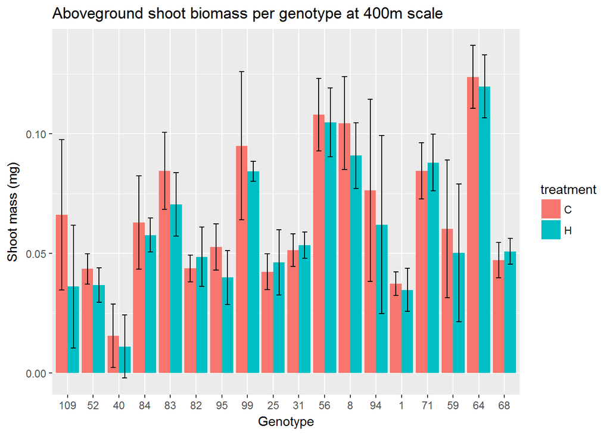

```r
p.AG.400
```

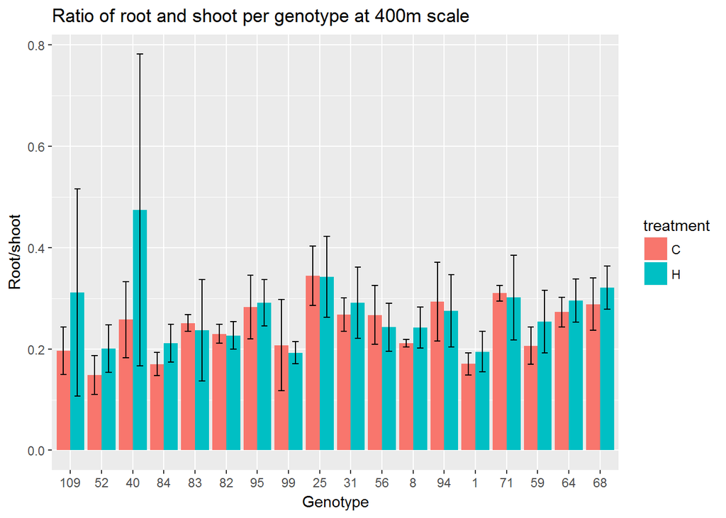

```r
p.rs.400
```

# **5.5 AT 800m scale**

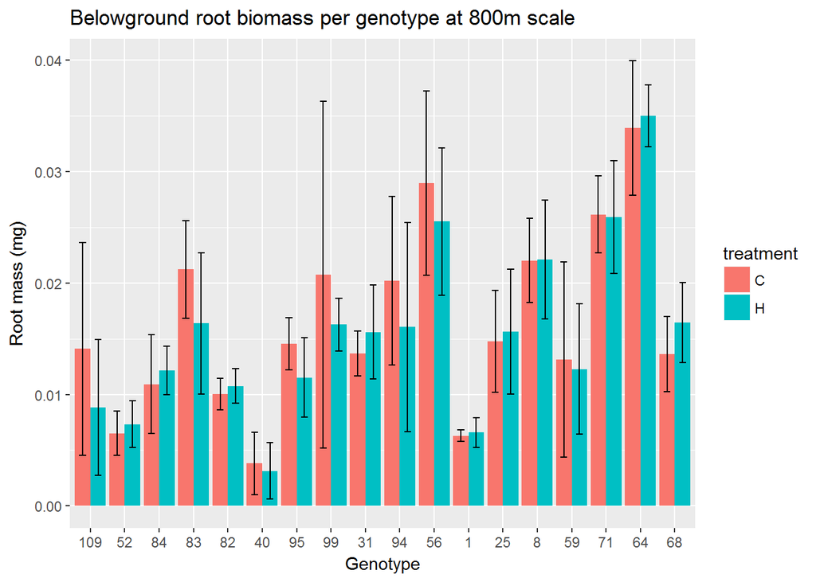

```r
## order genotypes by specifying urbanisation at 800m scale
mass.geno.BU <- mass.geno.BU %>%
  arrange(d800) %>%
  mutate(genotype = factor(genotype, unique(genotype)))
## plot
p.BG.800 <- ggplot(mass.geno.BU, aes(x=genotype, y=mBG, fill=treatment)) +
  geom_bar(stat = "identity",
           position = position_dodge()) +
  geom_errorbar(aes(ymin=mBG-sd.BG, ymax=mBG+sd.BG), width=.4,
                position = position_dodge(.9)) +
  labs(title = "Belowground root biomass per genotype at 800m scale", x = "Genotype", y = "Root mass (mg)")

p.AG.800 <- ggplot(mass.geno.BU, aes(x=genotype, y=mAG, fill=treatment)) +
  geom_bar(stat = "identity",
           position = position_dodge()) +
  geom_errorbar(aes(ymin=mAG-sd.AG, ymax=mAG+sd.AG), width=.4,
                position = position_dodge(.9)) +
  labs(title = "Aboveground shoot biomass per genotype at 800m scale", x = "Genotype", y = "Shoot mass (mg)")

p.rs.800 <- ggplot(mass.geno.BU, aes(x=genotype, y=mratio, fill=treatment)) +
  geom_bar(stat = "identity",
           position = position_dodge()) +
  geom_errorbar(aes(ymin=mratio-sd.ratio, ymax=mratio+sd.ratio), width=.4,
                position = position_dodge(.9)) +
  labs(title = "Ratio of root and shoot per genotype at 800m scale", x = "Genotype", y = "Root/shoot")

p.BG.800
```

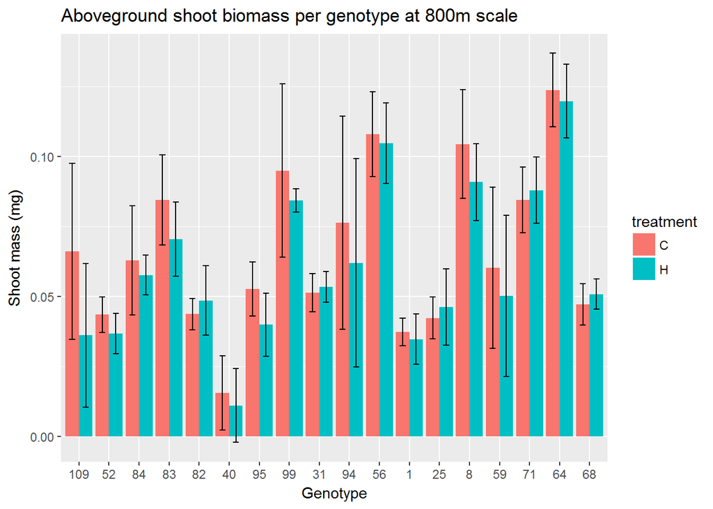

```r
p.AG.800
```

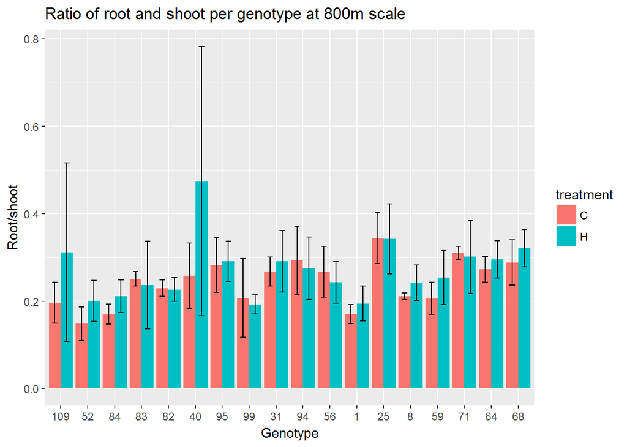

```r
p.rs.800
```

# **5.6 AT 1600m scale**

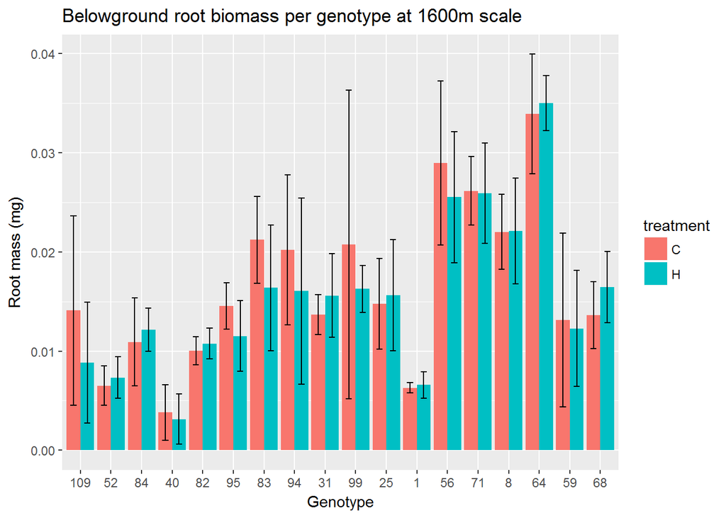

```r
## order genotypes by specifying urbanisation at 1600m scale
mass.geno.BU <- mass.geno.BU %>%
  arrange(d1600) %>%
  mutate(genotype = factor(genotype, unique(genotype)))
## plot
p.BG.1600 <- ggplot(mass.geno.BU, aes(x=genotype, y=mBG, fill=treatment)) +
  geom_bar(stat = "identity",
           position = position_dodge()) +
  geom_errorbar(aes(ymin=mBG-sd.BG, ymax=mBG+sd.BG), width=.4,
                position = position_dodge(.9)) +
  labs(title = "Belowground root biomass per genotype at 1600m scale", x = "Genotype", y = "Root mass (mg)")

p.AG.1600 <- ggplot(mass.geno.BU, aes(x=genotype, y=mAG, fill=treatment)) +
  geom_bar(stat = "identity",
           position = position_dodge()) +
  geom_errorbar(aes(ymin=mAG-sd.AG, ymax=mAG+sd.AG), width=.4,
                position = position_dodge(.9)) +
  labs(title = "Aboveground shoot biomass per genotype at 1600m scale", x = "Genotype", y = "Shoot mass (mg)")

p.rs.1600 <- ggplot(mass.geno.BU, aes(x=genotype, y=mratio, fill=treatment)) +
  geom_bar(stat = "identity",
           position = position_dodge()) +
  geom_errorbar(aes(ymin=mratio-sd.ratio, ymax=mratio+sd.ratio), width=.4,
                position = position_dodge(.9)) +
  labs(title = "Ratio of root and shoot per genotype at 1600m scale", x = "Genotype", y = "Root/shoot")

p.BG.1600
```

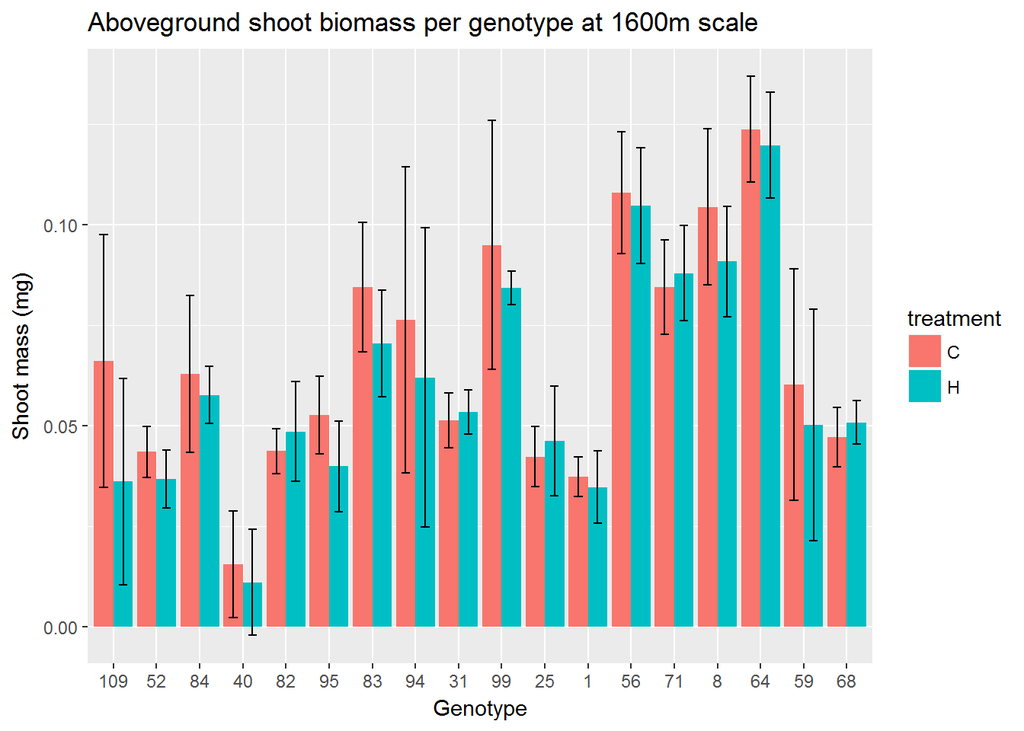

```r
p.AG.1600
```

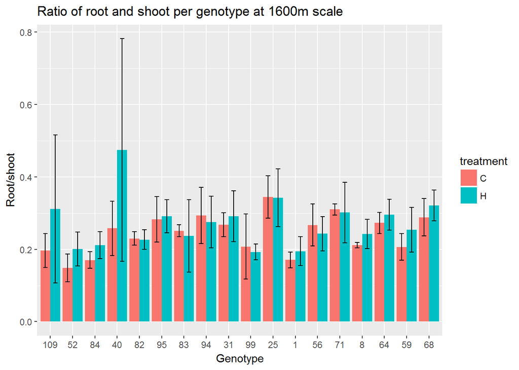

```r
p.rs.1600
```

# **5.7 AT 2400m scale**

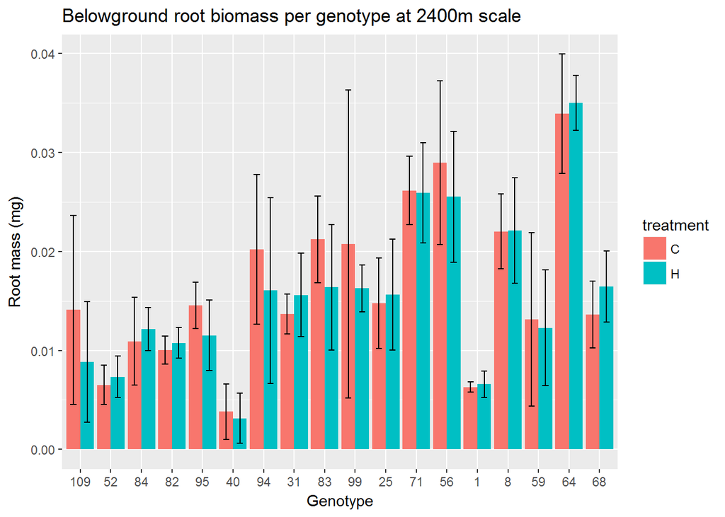

```r
## order genotypes by specifying urbanisation at 2400m scale
mass.geno.BU <- mass.geno.BU %>%
  arrange(d2400) %>%
  mutate(genotype = factor(genotype, unique(genotype)))
## plot
p.BG.2400 <- ggplot(mass.geno.BU, aes(x=genotype, y=mBG, fill=treatment)) +
  geom_bar(stat = "identity",
           position = position_dodge()) +
  geom_errorbar(aes(ymin=mBG-sd.BG, ymax=mBG+sd.BG), width=.4,
                position = position_dodge(.9)) +
  labs(title = "Belowground root biomass per genotype at 2400m scale", x = "Genotype", y = "Root mass (mg)")

p.AG.2400 <- ggplot(mass.geno.BU, aes(x=genotype, y=mAG, fill=treatment)) +
  geom_bar(stat = "identity",
           position = position_dodge()) +
  geom_errorbar(aes(ymin=mAG-sd.AG, ymax=mAG+sd.AG), width=.4,
                position = position_dodge(.9)) +
  labs(title = "Aboveground shoot biomass per genotype at 2400m scale", x = "Genotype", y = "Shoot mass (mg)")

p.rs.2400 <- ggplot(mass.geno.BU, aes(x=genotype, y=mratio, fill=treatment)) +
  geom_bar(stat = "identity",
           position = position_dodge()) +
  geom_errorbar(aes(ymin=mratio-sd.ratio, ymax=mratio+sd.ratio), width=.4,
                position = position_dodge(.9)) +
  labs(title = "Ratio of root and shoot per genotype at 2400m scale", x = "Genotype", y = "Root/shoot")

p.BG.2400
```

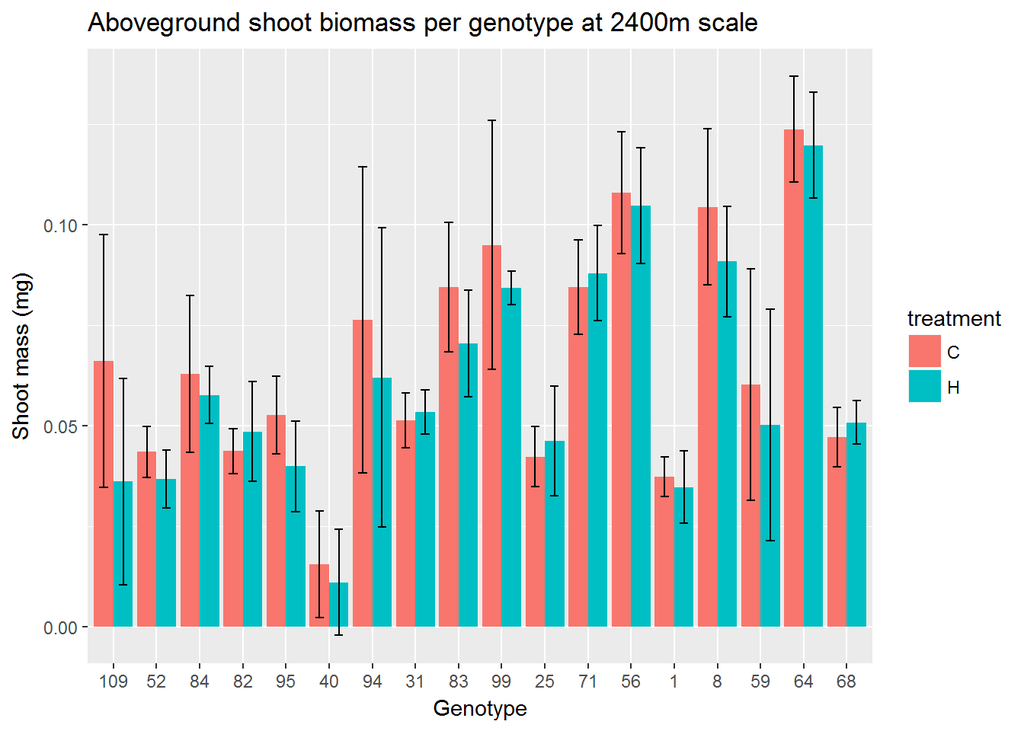

```r
p.AG.2400
```

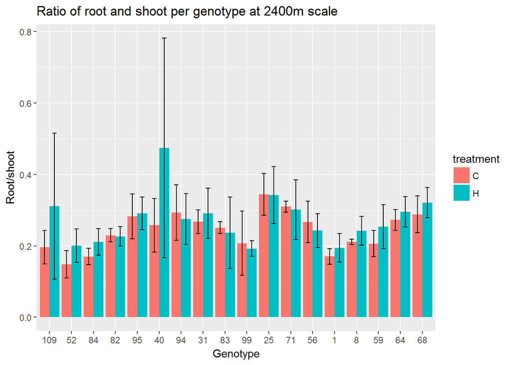

```r
p.rs.2400
```

# **5.8 AT 3200m scale**

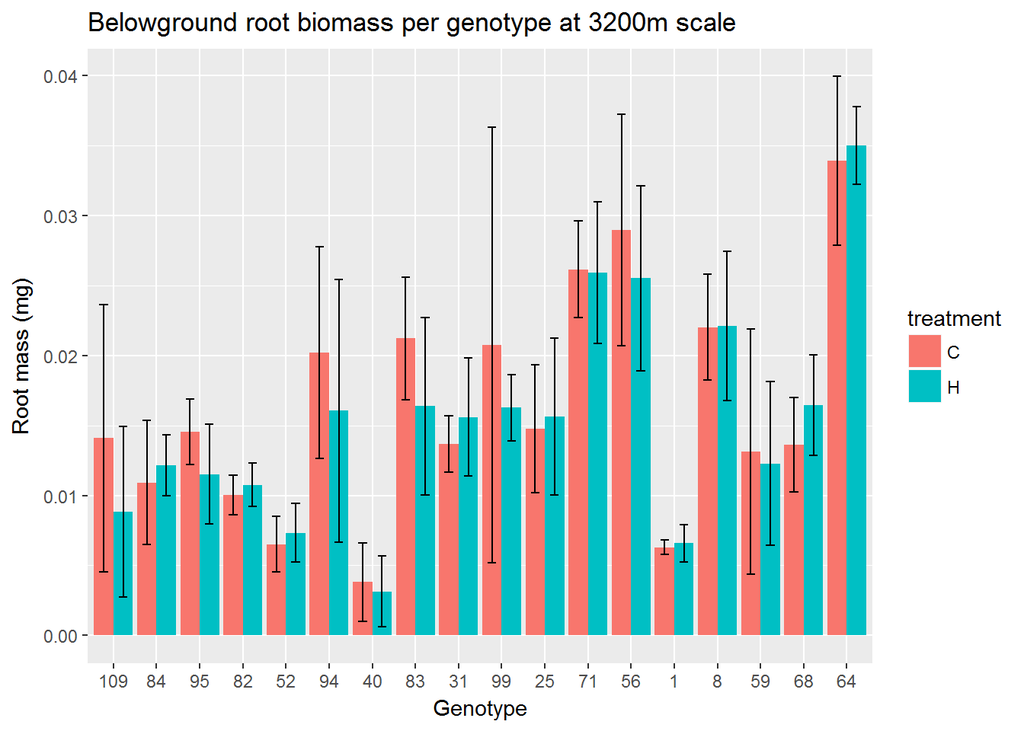

```r
## order genotypes by specifying urbanisation at 3200m scale
mass.geno.BU <- mass.geno.BU %>%
  arrange(d3200) %>%
  mutate(genotype = factor(genotype, unique(genotype)))
## plot
p.BG.3200 <- ggplot(mass.geno.BU, aes(x=genotype, y=mBG, fill=treatment)) +
  geom_bar(stat = "identity",
           position = position_dodge()) +
  geom_errorbar(aes(ymin=mBG-sd.BG, ymax=mBG+sd.BG), width=.4,
                position = position_dodge(.9)) +
  labs(title = "Belowground root biomass per genotype at 3200m scale", x = "Genotype", y = "Root mass (mg)")

p.AG.3200 <- ggplot(mass.geno.BU, aes(x=genotype, y=mAG, fill=treatment)) +
  geom_bar(stat = "identity",
           position = position_dodge()) +
  geom_errorbar(aes(ymin=mAG-sd.AG, ymax=mAG+sd.AG), width=.4,
                position = position_dodge(.9)) +
  labs(title = "Aboveground shoot biomass per genotype at 3200m scale", x = "Genotype", y = "Shoot mass (mg)")

p.rs.3200 <- ggplot(mass.geno.BU, aes(x=genotype, y=mratio, fill=treatment)) +
  geom_bar(stat = "identity",
           position = position_dodge()) +
  geom_errorbar(aes(ymin=mratio-sd.ratio, ymax=mratio+sd.ratio), width=.4,
                position = position_dodge(.9)) +
  labs(title = "Ratio of root and shoot per genotype at 3200m scale", x = "Genotype", y = "Root/shoot")

p.BG.3200
```

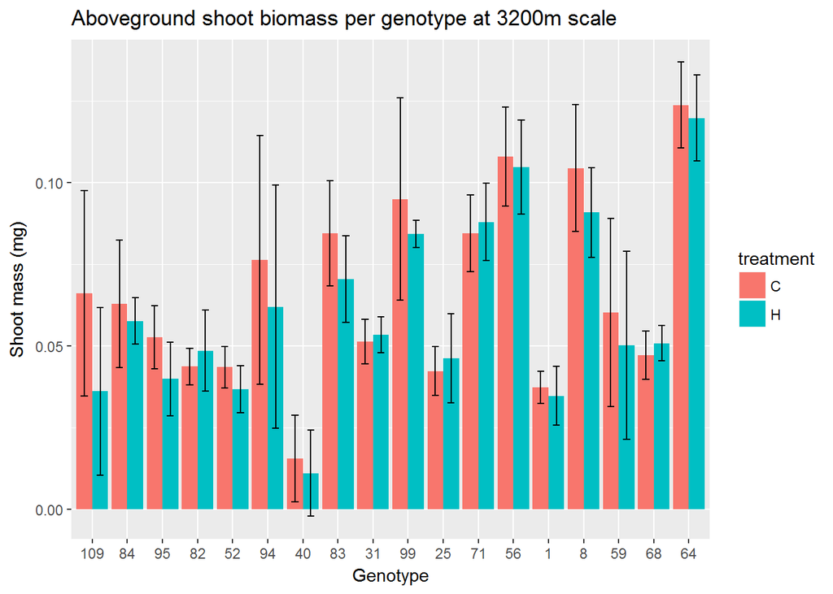

```r
p.AG.3200
```

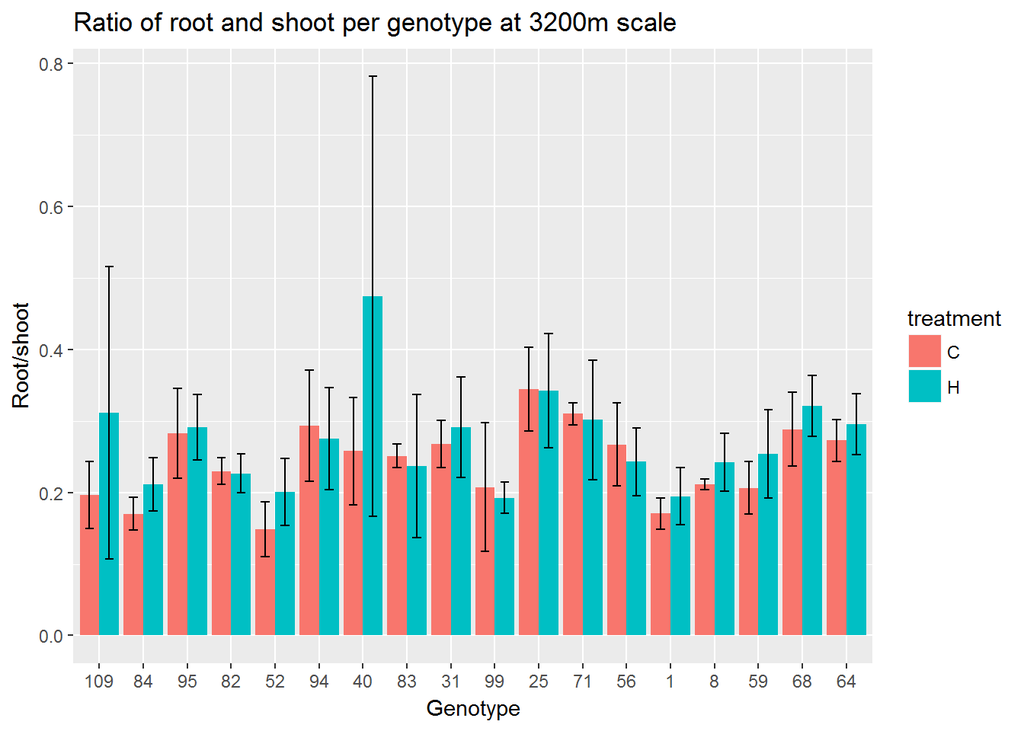

```r
p.rs.3200
```

Results: (1) From these error bar plots, it is clear that treatment has no effect on root and shoot biomass of each genotype, while probable effect on root/shoot ratio.

2. There may be difference in root and shoot biomass among genotypes, while not in root/shoot ratio.
3. It seems that root and shoot biomass in urban area are larger than that in rural area.

# **5.9 Perform lm model tests**

Model: biomass ~ herbivory * genotype

```r
# select working dataframes:  "plant.biomass"
## calculate root:shoot ratio of biomass: "plant.biomass"
biomass_HT <- plant.biomass %>%
  mutate(ratio = BG.biomass/AG.biomass)
View(biomass_HT)

#### lm test whether the effect of herbivory differs for different genotypes.
lm.BG <- lm(formula = BG.biomass ~ genotype*treatment, data = biomass_HT)
summary(lm.BG)
```

```
##
## Call:
## lm(formula = BG.biomass ~ genotype * treatment, data = biomass_HT)
##
## Residuals:
##       Min        1Q    Median        3Q       Max
## -0.014641 -0.006977 -0.002240  0.005528  0.030198
##
## Coefficients:
##                       Estimate Std. Error t value Pr(>|t|)
## (Intercept)          1.323e-02  2.207e-03   5.994 1.13e-08 ***
## genotype             5.020e-05  3.184e-05   1.577    0.117
## treatmentH           1.916e-03  3.122e-03   0.614    0.540
## genotype:treatmentH -4.596e-05  4.502e-05  -1.021    0.309
## ---
## Signif. codes:  0 '***' 0.001 '**' 0.01 '*' 0.05 '.' 0.1 ' ' 1
##
## Residual standard error: 0.009208 on 176 degrees of freedom
## Multiple R-squared:  0.01665,    Adjusted R-squared:  -0.0001131
## F-statistic: 0.9933 on 3 and 176 DF,  p-value: 0.3973
```

```r
anova(lm.BG)
```

```
## Analysis of Variance Table
##
## Response: BG.biomass
##                     Df    Sum Sq    Mean Sq F value Pr(>F)
## genotype             1 0.0001240 1.2396e-04  1.4619 0.2282
## treatment            1 0.0000403 4.0328e-05  0.4756 0.4913
## genotype:treatment   1 0.0000884 8.8366e-05  1.0422 0.3087
## Residuals          176 0.0149229 8.4789e-05
```

```r
lm.AG <- lm(formula = AG.biomass ~ genotype*treatment, data = biomass_HT)
summary(lm.AG)
```

```
##
## Call:
## lm(formula = AG.biomass ~ genotype * treatment, data = biomass_HT)
##
## Residuals:
##       Min        1Q    Median        3Q       Max
## -0.058925 -0.021565 -0.007427  0.026230  0.077825
##
## Coefficients:
##                       Estimate Std. Error t value Pr(>|t|)
## (Intercept)          0.0550869  0.0075718   7.275  1.1e-11 ***
## genotype             0.0001860  0.0001092   1.703   0.0903 .
## treatmentH           0.0011973  0.0107082   0.112   0.9111
## genotype:treatmentH -0.0001209  0.0001544  -0.783   0.4348
## ---
## Signif. codes:  0 '***' 0.001 '**' 0.01 '*' 0.05 '.' 0.1 ' ' 1
##
## Residual standard error: 0.03158 on 176 degrees of freedom
## Multiple R-squared:  0.02796,    Adjusted R-squared:  0.01139
## F-statistic: 1.688 on 3 and 176 DF,  p-value: 0.1714
```

```r
anova(lm.AG)
```

```
## Analysis of Variance Table
##
## Response: AG.biomass
##                     Df   Sum Sq    Mean Sq F value Pr(>F)
## genotype             1 0.002636 0.00263585  2.6423 0.1058
## treatment            1 0.001804 0.00180373  1.8081 0.1805
## genotype:treatment   1 0.000611 0.00061125  0.6127 0.4348
## Residuals          176 0.175571 0.00099756
```

```r
lm.ratio <- lm(formula = ratio ~ genotype*treatment, data = biomass_HT)
summary(lm.ratio)
```

```
##
## Call:
## lm(formula = ratio ~ genotype * treatment, data = biomass_HT)
##
## Residuals:
##      Min       1Q   Median       3Q      Max
## -0.15848 -0.05970 -0.01241  0.04164  0.72346
##
## Coefficients:
##                       Estimate Std. Error t value Pr(>|t|)
## (Intercept)          2.398e-01  2.257e-02  10.623   <2e-16 ***
## genotype             5.171e-05  3.255e-04   0.159    0.874
## treatmentH           4.415e-02  3.192e-02   1.383    0.168
## genotype:treatmentH -2.365e-04  4.604e-04  -0.514    0.608
## ---
## Signif. codes:  0 '***' 0.001 '**' 0.01 '*' 0.05 '.' 0.1 ' ' 1
##
## Residual standard error: 0.09416 on 176 degrees of freedom
## Multiple R-squared:  0.02624,    Adjusted R-squared:  0.009646
## F-statistic: 1.581 on 3 and 176 DF,  p-value: 0.1956
```

```r
anova(lm.ratio)
```

```
## Analysis of Variance Table
##
## Response: ratio
##                     Df  Sum Sq  Mean Sq F value  Pr(>F)
## genotype             1 0.00074 0.000740  0.0835 0.77294
## treatment            1 0.03897 0.038973  4.3961 0.03745 *
## genotype:treatment   1 0.00234 0.002339  0.2638 0.60816
## Residuals          176 1.56029 0.008865
## ---
## Signif. codes:  0 '***' 0.001 '**' 0.01 '*' 0.05 '.' 0.1 ' ' 1
```

```r
#test differences of trichome between treatment and among genotypes
## dataframe:"trichome"
lm.trichome <- lm(formula = trichome ~ genotype*treatment, data = trichome)
summary(lm.trichome)
```

```
##
## Call:
## lm(formula = trichome ~ genotype * treatment, data = trichome)
##
## Residuals:
##     Min      1Q  Median      3Q     Max
## -29.040  -2.295  -0.110   3.220  34.960
##
## Coefficients:
##                          Estimate Std. Error t value Pr(>|t|)
## (Intercept)             4.214e+01  3.741e+00  11.265  < 2e-16 ***
## genotype8              -2.716e+01  5.290e+00  -5.134 9.04e-07 ***
## genotype25             -9.140e+00  5.290e+00  -1.728 0.086185 .
## genotype31             -1.680e+00  5.290e+00  -0.318 0.751275
## genotype40              2.090e+01  5.290e+00   3.951 0.000122 ***
## genotype52             -2.200e-01  5.290e+00  -0.042 0.966886
## genotype56             -2.402e+01  5.290e+00  -4.540 1.18e-05 ***
## genotype59             -1.018e+01  5.290e+00  -1.924 0.056290 .
## genotype64             -1.952e+01  5.290e+00  -3.690 0.000318 ***
## genotype68             -1.282e+01  5.290e+00  -2.423 0.016620 *
## genotype71             -1.536e+01  5.290e+00  -2.903 0.004272 **
## genotype82              6.260e+00  5.290e+00   1.183 0.238637
## genotype83             -2.190e+01  5.290e+00  -4.140 5.90e-05 ***
## genotype84              1.264e+01  5.290e+00   2.389 0.018175 *
## genotype94             -1.980e+01  5.290e+00  -3.743 0.000262 ***
## genotype95              4.560e+00  5.290e+00   0.862 0.390141
## genotype99             -2.196e+01  5.290e+00  -4.151 5.64e-05 ***
## genotype109            -4.960e+00  5.290e+00  -0.938 0.350033
## treatmentH              2.620e+00  5.290e+00   0.495 0.621178
## genotype8:treatmentH    5.195e-14  7.482e+00   0.000 1.000000
## genotype25:treatmentH  -7.000e+00  7.482e+00  -0.936 0.351027
## genotype31:treatmentH  -7.500e+00  7.482e+00  -1.002 0.317800
## genotype40:treatmentH  -4.880e+00  7.482e+00  -0.652 0.515266
## genotype52:treatmentH  -7.440e+00  7.482e+00  -0.994 0.321673
## genotype56:treatmentH  -1.380e+00  7.482e+00  -0.184 0.853917
## genotype59:treatmentH   3.600e-01  7.482e+00   0.048 0.961689
## genotype64:treatmentH  -3.720e+00  7.482e+00  -0.497 0.619790
## genotype68:treatmentH  -2.660e+00  7.482e+00  -0.356 0.722704
## genotype71:treatmentH  -3.320e+00  7.482e+00  -0.444 0.657883
## genotype82:treatmentH  -6.320e+00  7.482e+00  -0.845 0.399654
## genotype83:treatmentH  -1.120e+00  7.482e+00  -0.150 0.881209
## genotype84:treatmentH  -1.204e+01  7.482e+00  -1.609 0.109742
## genotype94:treatmentH   7.400e-01  7.482e+00   0.099 0.921347
## genotype95:treatmentH  -3.020e+00  7.482e+00  -0.404 0.687062
## genotype99:treatmentH  -2.200e-01  7.482e+00  -0.029 0.976582
## genotype109:treatmentH  1.714e+01  7.482e+00   2.291 0.023416 *
## ---
## Signif. codes:  0 '***' 0.001 '**' 0.01 '*' 0.05 '.' 0.1 ' ' 1
##
## Residual standard error: 8.365 on 144 degrees of freedom
## Multiple R-squared:  0.7496, Adjusted R-squared:  0.6887
## F-statistic: 12.31 on 35 and 144 DF,  p-value: < 2.2e-16
```

```r
anova(lm.trichome)
```

```
## Analysis of Variance Table
##
## Response: trichome
##                     Df  Sum Sq Mean Sq F value Pr(>F)
## genotype            17 28630.4 1684.14 24.0705 <2e-16 ***
## treatment            1     3.2    3.17  0.0454 0.8317
## genotype:treatment  17  1520.7   89.45  1.2785 0.2143
## Residuals          144 10075.2   69.97
## ---
## Signif. codes:  0 '***' 0.001 '**' 0.01 '*' 0.05 '.' 0.1 ' ' 1
```

Results: (1) There are no significant influences of herbivory treatment on root and shoot biomass and no differences among genotypes as well.

2. However, a significant influence of treatment on root/shoot ratio (P = 0.0375).
3. Number of trichome differs among genotypes (P = <2e-16).

# **6 Effects of herbivory on average biomass per genotype along with urbanisation**

Model: “average biomass per genotype” ~ herbivory * urbanization

```r
# load library
library(lme4)
# select working dataframes: "mass.geno.BU"(with means)
```

# **6.1 Effect of herbivory and urbanisation on average root biomass among genotypes**

```r
# create lm models

lm.mr.50 <- lm(mBG ~ treatment*d50, data = mass.geno.BU)
lm.mr.100 <- lm(mBG ~ treatment*d100, data = mass.geno.BU)
lm.mr.200 <- lm(mBG ~ treatment*d200, data = mass.geno.BU)
lm.mr.400 <- lm(mBG ~ treatment*d400, data = mass.geno.BU)
lm.mr.800 <- lm(mBG ~ treatment*d800, data = mass.geno.BU)
lm.mr.1600 <- lm(mBG ~ treatment*d1600, data = mass.geno.BU)
lm.mr.2400 <- lm(mBG ~ treatment*d2400, data = mass.geno.BU)
lm.mr.3200 <- lm(mBG ~ treatment*d3200, data = mass.geno.BU)

AIC(lm.mr.50, lm.mr.100, lm.mr.200, lm.mr.400, lm.mr.800, lm.mr.1600, lm.mr.2400, lm.mr.3200)    ##### model at d200 has lowest AIC value.
```

```
##            df       AIC
## lm.mr.50    5 -249.0951
## lm.mr.100   5 -252.6170
## lm.mr.200   5 -254.1359
## lm.mr.400   5 -249.0427
## lm.mr.800   5 -251.0995
## lm.mr.1600  5 -250.2979
## lm.mr.2400  5 -249.8975
## lm.mr.3200  5 -249.2145
```

```r
#summarize model d200
summary(lm.mr.200)
```

```
##
## Call:
## lm(formula = mBG ~ treatment * d200, data = mass.geno.BU)
##
## Residuals:
##       Min        1Q    Median        3Q       Max
## -0.012553 -0.003266 -0.000448  0.003843  0.012097
##
## Coefficients:
##                   Estimate Std. Error t value Pr(>|t|)
## (Intercept)      8.012e-03  3.445e-03   2.326   0.0265 *
## treatmentH      -2.719e-03  4.871e-03  -0.558   0.5806
## d200             3.333e-04  1.230e-04   2.710   0.0107 *
## treatmentH:d200  7.077e-05  1.739e-04   0.407   0.6868
## ---
## Signif. codes:  0 '***' 0.001 '**' 0.01 '*' 0.05 '.' 0.1 ' ' 1
##
## Residual standard error: 0.006548 on 32 degrees of freedom
## Multiple R-squared:  0.3642, Adjusted R-squared:  0.3046
## F-statistic:  6.11 on 3 and 32 DF,  p-value: 0.002084
```

```r
anova(lm.mr.200)
```

```
## Analysis of Variance Table
##
## Response: mBG
##                Df     Sum Sq    Mean Sq F value    Pr(>F)
## treatment       1 0.00000807 0.00000807  0.1881 0.6674002
## d200            1 0.00077081 0.00077081 17.9777 0.0001776 ***
## treatment:d200  1 0.00000710 0.00000710  0.1656 0.6867675
## Residuals      32 0.00137203 0.00004288
## ---
## Signif. codes:  0 '***' 0.001 '**' 0.01 '*' 0.05 '.' 0.1 ' ' 1
```

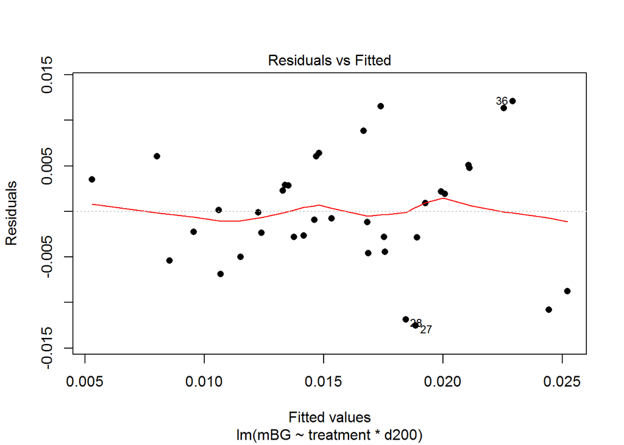

```r
# visualize residuals and fitted values.
plot(lm.mr.200, pch=16, which=1)
```

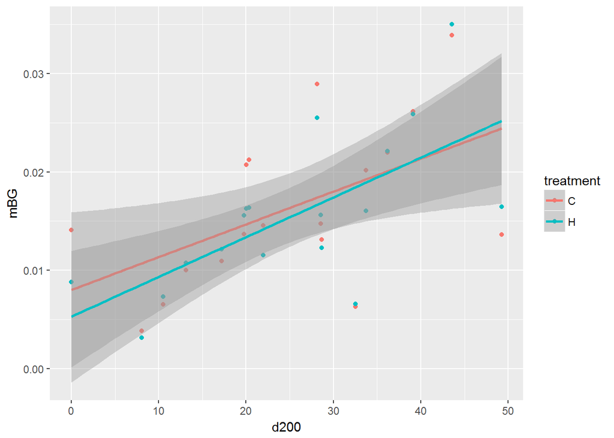

```r
# plot mod d200
p.mr.200 <- ggplot(mass.geno.BU, aes(d200, mBG, color = treatment)) +
  geom_point() +
  stat_smooth(method = "lm", fullrange=FALSE)
p.mr.200
```

Results: (1) The best model is at 200m scale (R2=0.3046).

2. Treatment has no effect on average root biomass per genotype, while urbanisation (d200) has significant effect on it (P=0.0107).

# **6.2 Effect of herbivory and urbanisation on average shoot biomass among genotypes**

```r
# create lm models

lm.ms.50 <- lm(mAG ~ treatment*d50, data = mass.geno.BU)
lm.ms.100 <- lm(mAG ~ treatment*d100, data = mass.geno.BU)
lm.ms.200 <- lm(mAG ~ treatment*d200, data = mass.geno.BU)
lm.ms.400 <- lm(mAG ~ treatment*d400, data = mass.geno.BU)
lm.ms.800 <- lm(mAG ~ treatment*d800, data = mass.geno.BU)
lm.ms.1600 <- lm(mAG ~ treatment*d1600, data = mass.geno.BU)
lm.ms.2400 <- lm(mAG ~ treatment*d2400, data = mass.geno.BU)
lm.ms.3200 <- lm(mAG ~ treatment*d3200, data = mass.geno.BU)

AIC(lm.ms.50, lm.ms.100, lm.ms.200, lm.ms.400, lm.ms.800, lm.ms.1600, lm.ms.2400, lm.ms.3200)  ## model d100 has lowest AIC score.
```

```
##            df       AIC
## lm.ms.50    5 -153.8244
## lm.ms.100   5 -156.4130
## lm.ms.200   5 -156.3989
## lm.ms.400   5 -153.1062
## lm.ms.800   5 -153.3398
## lm.ms.1600  5 -154.8108
## lm.ms.2400  5 -155.6596
## lm.ms.3200  5 -155.2273
```

```r
#summarize model d100
summary(lm.ms.100)
```

```
##
## Call:
## lm(formula = mAG ~ treatment * d100, data = mass.geno.BU)
##
## Residuals:
##       Min        1Q    Median        3Q       Max
## -0.042759 -0.014215 -0.001522  0.019228  0.044726
##
## Coefficients:
##                   Estimate Std. Error t value Pr(>|t|)
## (Intercept)      0.0437610  0.0133958   3.267   0.0026 **
## treatmentH      -0.0129223  0.0189445  -0.682   0.5001
## d100             0.0008969  0.0004690   1.912   0.0648 .
## treatmentH:d100  0.0002581  0.0006633   0.389   0.6998
## ---
## Signif. codes:  0 '***' 0.001 '**' 0.01 '*' 0.05 '.' 0.1 ' ' 1
##
## Residual standard error: 0.02544 on 32 degrees of freedom
## Multiple R-squared:  0.2431, Adjusted R-squared:  0.1722
## F-statistic: 3.426 on 3 and 32 DF,  p-value: 0.02866
```

```r
anova(lm.ms.100)
```

```
## Analysis of Variance Table
##
## Response: mAG
##                Df    Sum Sq   Mean Sq F value   Pr(>F)
## treatment       1 0.0003607 0.0003607  0.5573 0.460801
## d100            1 0.0061947 0.0061947  9.5698 0.004085 **
## treatment:d100  1 0.0000980 0.0000980  0.1514 0.699790
## Residuals      32 0.0207141 0.0006473
## ---
## Signif. codes:  0 '***' 0.001 '**' 0.01 '*' 0.05 '.' 0.1 ' ' 1
```

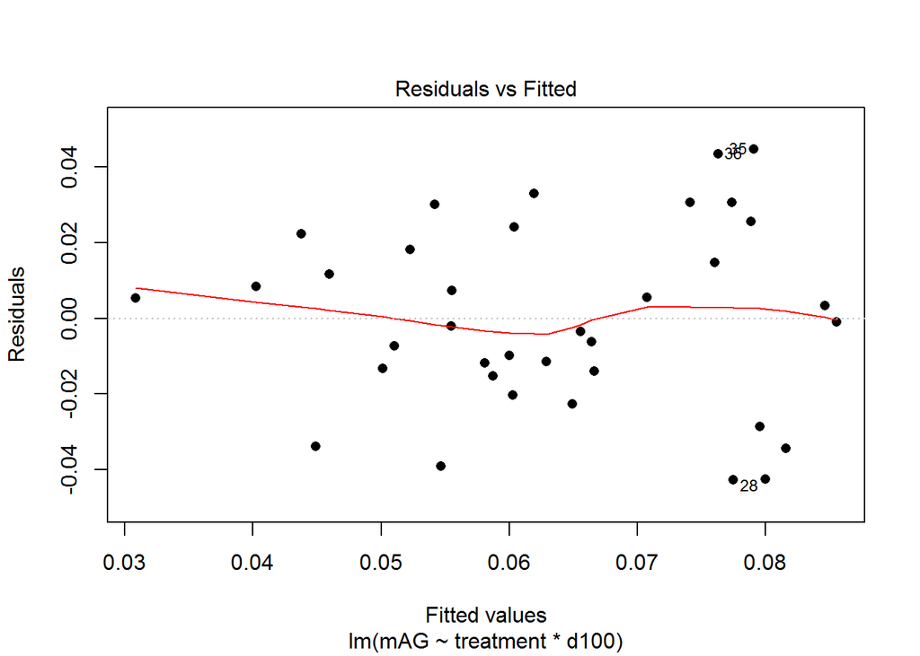

```r
# visualize residuals and fitted values.
plot(lm.ms.100, pch=16, which=1)
```

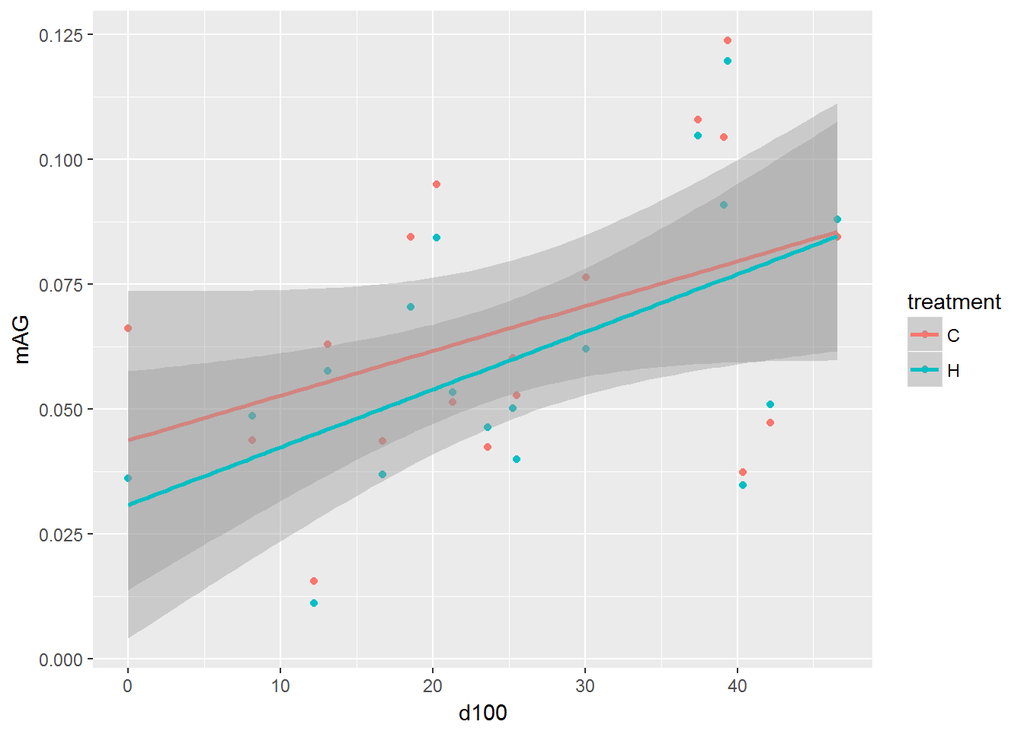

```r
# plot
p.ms.100 <- ggplot(mass.geno.BU, aes(d100, mAG, color = treatment)) +
  geom_point() +
  stat_smooth(method = "lm", fullrange=FALSE)
p.ms.100
```

Results: (1) The best model is at 100m scale (R2=0.1722).

2. But both treatment and urbanisation do not have effects on average shoot biomass per genotype.

# **6.3 Effect of herbivory and urbanisation on average ratio of root and shoot among genotypes**

```r
# create lm models
lm.mrs.50 <- lm(mratio ~ treatment*d50, data = mass.geno.BU)
lm.mrs.100 <- lm(mratio ~ treatment*d100, data = mass.geno.BU)
lm.mrs.200 <- lm(mratio ~ treatment*d200, data = mass.geno.BU)
lm.mrs.400 <- lm(mratio ~ treatment*d400, data = mass.geno.BU)
lm.mrs.800 <- lm(mratio ~ treatment*d800, data = mass.geno.BU)
lm.mrs.1600 <- lm(mratio ~ treatment*d1600, data = mass.geno.BU)
lm.mrs.2400 <- lm(mratio ~ treatment*d2400, data = mass.geno.BU)
lm.mrs.3200 <- lm(mratio ~ treatment*d3200, data = mass.geno.BU)

AIC(lm.mrs.50, lm.mrs.100, lm.mrs.200, lm.mrs.400, lm.mrs.800, lm.mrs.1600, lm.mrs.2400, lm.mrs.3200)   ## model d800 has lowest AIC value.
```

```
##             df       AIC
## lm.mrs.50    5 -93.29711
## lm.mrs.100   5 -93.15645
## lm.mrs.200   5 -94.13006
## lm.mrs.400   5 -93.46554
## lm.mrs.800   5 -95.46631
## lm.mrs.1600  5 -92.92905
## lm.mrs.2400  5 -91.98853
## lm.mrs.3200  5 -91.95331
```

```r
#summarize model d800
summary(lm.mrs.800)
```

```
##
## Call:
## lm(formula = mratio ~ treatment * d800, data = mass.geno.BU)
##
## Residuals:
##       Min        1Q    Median        3Q       Max
## -0.087038 -0.040611  0.001999  0.033110  0.207574
##
## Coefficients:
##                  Estimate Std. Error t value Pr(>|t|)
## (Intercept)      0.190455   0.030501   6.244 5.36e-07 ***
## treatmentH       0.065672   0.043135   1.522   0.1377
## d800             0.002067   0.001066   1.938   0.0614 .
## treatmentH:d800 -0.001426   0.001508  -0.945   0.3515
## ---
## Signif. codes:  0 '***' 0.001 '**' 0.01 '*' 0.05 '.' 0.1 ' ' 1
##
## Residual standard error: 0.05932 on 32 degrees of freedom
## Multiple R-squared:  0.1652, Adjusted R-squared:  0.08697
## F-statistic: 2.111 on 3 and 32 DF,  p-value: 0.1183
```

```r
anova(lm.mrs.800)
```

```
## Analysis of Variance Table
##
## Response: mratio
##                Df   Sum Sq   Mean Sq F value  Pr(>F)
## treatment       1 0.007795 0.0077946  2.2153 0.14644
## d800            1 0.011347 0.0113470  3.2249 0.08197 .
## treatment:d800  1 0.003145 0.0031447  0.8938 0.35154
## Residuals      32 0.112593 0.0035185
## ---
## Signif. codes:  0 '***' 0.001 '**' 0.01 '*' 0.05 '.' 0.1 ' ' 1
```

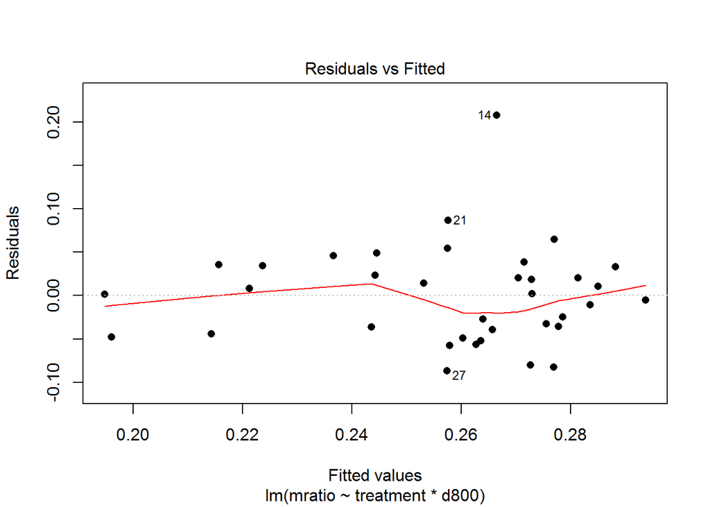

```r
# visualize residuals and fitted values.
plot(lm.mrs.800, pch=16, which=1)
```

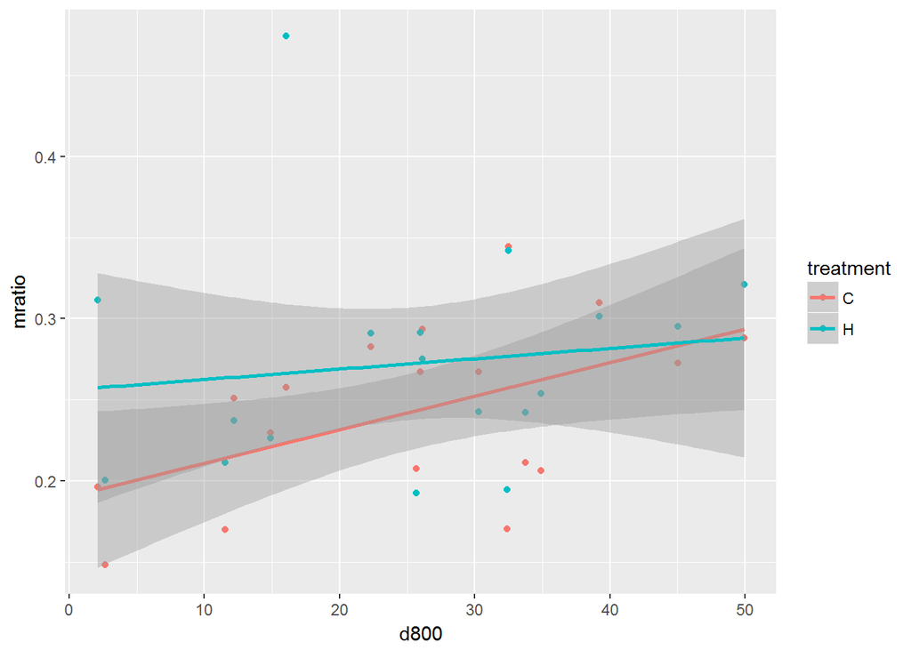

```r
# plot
p.mrs.800 <- ggplot(mass.geno.BU, aes(d800, mratio, color = treatment)) +
  geom_point() +
  stat_smooth(method = "lm", fullrange=FALSE)
p.mrs.800
```

Results: (1) The best model is at 800m scale (R2=0.08697).

# **7. Differences of biomass along with urbanisation**

Model: “difference between average biomass of a certain genotype in the herbivory and control treatment” ~ urbanization Test how the difference between herbivory and control changes with urbanization.

```r
# select working dataframe: "mass.geno.BU"(with means)

# calculate difference of average biomass between herbivory and control treatment
df <- data.frame(genotype = mass.geno.BU[mass.geno.BU$treatment == "C", "genotype"],
                   df.BG = mass.geno.BU[mass.geno.BU$treatment == "C", "mBG"] - mass.geno.BU[mass.geno.BU$treatment == "H", "mBG"],
                   df.AG = mass.geno.BU[mass.geno.BU$treatment == "C", "mAG"] - mass.geno.BU[mass.geno.BU$treatment == "H", "mAG"],
                   df.rs = mass.geno.BU[mass.geno.BU$treatment == "C", "mratio"] - mass.geno.BU[mass.geno.BU$treatment == "H", "mratio"])

# creat new working dataframe: merge "diff" and "BU"
df.BU <- merge(df, BU, by = "genotype")
View(df.BU)

## Root biomass
lm.dfBG.50 <- lm(df.BG ~ d50, data = df.BU)
lm.dfBG.100 <- lm(df.BG ~ d100, data = df.BU)
lm.dfBG.200 <- lm(df.BG ~ d200, data = df.BU)
lm.dfBG.400 <- lm(df.BG ~ d400, data = df.BU)
lm.dfBG.800 <- lm(df.BG ~ d800, data = df.BU)
lm.dfBG.1600 <- lm(df.BG ~ d1600, data = df.BU)
lm.dfBG.2400 <- lm(df.BG ~ d2400, data = df.BU)
lm.dfBG.3200 <- lm(df.BG ~ d3200, data = df.BU)

## shoot biomass
lm.dfAG.50 <- lm(df.AG ~ d50, data = df.BU)
lm.dfAG.100 <- lm(df.AG ~ d100, data = df.BU)
lm.dfAG.200 <- lm(df.AG ~ d200, data = df.BU)
lm.dfAG.400 <- lm(df.AG ~ d400, data = df.BU)
lm.dfAG.800 <- lm(df.AG ~ d800, data = df.BU)
lm.dfAG.1600 <- lm(df.AG ~ d1600, data = df.BU)
lm.dfAG.2400 <- lm(df.AG ~ d2400, data = df.BU)
lm.dfAG.3200 <- lm(df.AG ~ d3200, data = df.BU)

## Root/shoot ratio
lm.dfRS.50 <- lm(df.rs ~ d50, data = df.BU)
lm.dfRS.100 <- lm(df.rs ~ d100, data = df.BU)
lm.dfRS.200 <- lm(df.rs ~ d200, data = df.BU)
lm.dfRS.400 <- lm(df.rs ~ d400, data = df.BU)
lm.dfRS.800 <- lm(df.rs ~ d800, data = df.BU)
lm.dfRS.1600 <- lm(df.rs ~ d1600, data = df.BU)
lm.dfRS.2400 <- lm(df.rs ~ d2400, data = df.BU)
lm.dfRS.3200 <- lm(df.rs ~ d3200, data = df.BU)


## Model selection
AIC(lm.dfBG.50, lm.dfBG.100, lm.dfBG.200, lm.dfBG.400, lm.dfBG.800, lm.dfBG.1600, lm.dfBG.2400, lm.dfBG.3200)   ## model d800 has lowest AIC value.
```

```
##              df       AIC
## lm.dfBG.50    3 -159.8638
## lm.dfBG.100   3 -160.3653
## lm.dfBG.200   3 -161.3635
## lm.dfBG.400   3 -161.7465
## lm.dfBG.800   3 -161.8815
## lm.dfBG.1600  3 -161.3192
## lm.dfBG.2400  3 -161.0053
## lm.dfBG.3200  3 -161.2192
```

```r
AIC(lm.dfAG.50, lm.dfAG.100, lm.dfAG.200, lm.dfAG.400, lm.dfAG.800, lm.dfAG.1600, lm.dfAG.2400, lm.dfAG.3200)   ## model d800 has lowest AIC value.
```

```
##              df       AIC
## lm.dfAG.50    3 -115.9848
## lm.dfAG.100   3 -116.8266
## lm.dfAG.200   3 -117.2230
## lm.dfAG.400   3 -117.2954
## lm.dfAG.800   3 -118.6604
## lm.dfAG.1600  3 -117.1892
## lm.dfAG.2400  3 -116.0991
## lm.dfAG.3200  3 -116.6876
```

```r
AIC(lm.dfRS.50, lm.dfRS.100, lm.dfRS.200, lm.dfRS.400, lm.dfRS.800, lm.dfRS.1600, lm.dfRS.2400, lm.dfRS.3200)   ## model d200 has lowest AIC value.
```

```
##              df       AIC
## lm.dfRS.50    3 -50.86814
## lm.dfRS.100   3 -50.48098
## lm.dfRS.200   3 -51.43336
## lm.dfRS.400   3 -49.61758
## lm.dfRS.800   3 -48.85527
## lm.dfRS.1600  3 -48.38526
## lm.dfRS.2400  3 -47.96847
## lm.dfRS.3200  3 -47.97608
```

```r
## summarize best models
summary(lm.dfBG.800)
```

```
##
## Call:
## lm(formula = df.BG ~ d800, data = df.BU)
##
## Residuals:
##       Min        1Q    Median        3Q       Max
## -0.003429 -0.001796 -0.000533  0.002401  0.003552
##
## Coefficients:
##               Estimate Std. Error t value Pr(>|t|)
## (Intercept)  2.828e-03  1.245e-03   2.271   0.0373 *
## d800        -7.399e-05  4.353e-05  -1.700   0.1085
## ---
## Signif. codes:  0 '***' 0.001 '**' 0.01 '*' 0.05 '.' 0.1 ' ' 1
##
## Residual standard error: 0.002421 on 16 degrees of freedom
## Multiple R-squared:  0.1529, Adjusted R-squared:    0.1
## F-statistic: 2.889 on 1 and 16 DF,  p-value: 0.1085
```

```r
summary(lm.dfAG.800)
```

```
##
## Call:
## lm(formula = df.AG ~ d800, data = df.BU)
##
## Residuals:
##       Min        1Q    Median        3Q       Max
## -0.014522 -0.005428 -0.001519  0.005173  0.016339
##
## Coefficients:
##               Estimate Std. Error t value Pr(>|t|)
## (Intercept)  0.0143387  0.0041362   3.467  0.00318 **
## d800        -0.0003150  0.0001446  -2.178  0.04469 *
## ---
## Signif. codes:  0 '***' 0.001 '**' 0.01 '*' 0.05 '.' 0.1 ' ' 1
##
## Residual standard error: 0.008044 on 16 degrees of freedom
## Multiple R-squared:  0.2287, Adjusted R-squared:  0.1805
## F-statistic: 4.745 on 1 and 16 DF,  p-value: 0.04469
```

```r
summary(lm.dfRS.200)
```

```
##
## Call:
## lm(formula = df.rs ~ d200, data = df.BU)
##
## Residuals:
##       Min        1Q    Median        3Q       Max
## -0.150459 -0.025631  0.008012  0.028759  0.058098
##
## Coefficients:
##               Estimate Std. Error t value Pr(>|t|)
## (Intercept) -0.0829811  0.0273846  -3.030  0.00796 **
## d200         0.0021386  0.0009777   2.187  0.04390 *
## ---
## Signif. codes:  0 '***' 0.001 '**' 0.01 '*' 0.05 '.' 0.1 ' ' 1
##
## Residual standard error: 0.05206 on 16 degrees of freedom
## Multiple R-squared:  0.2302, Adjusted R-squared:  0.1821
## F-statistic: 4.785 on 1 and 16 DF,  p-value: 0.0439
```

Results: (1) The model d800 is best for “difference in root biomass” (R2=0.1) and “difference in shoot biomass”(R2=0.1805).

2. No significant difference is shown for “difference in root biomass”.
3. Although significant p-values of urbanisation are shown for shoot biomass (d800, p=0.04469) and root/shoot ratio (d200, p=0.0439), both models possess lower R2 (0.1805, 0.1821) and F values but larger residual standard errors compared to their means.

# **8. Difference of urban and rural genotypes**

Model: biomass ~ herbivory + genotype + herbivory x genotype + urbanization(categorical) + herbivory x urbanization(categorical)

# **8.1 at 50m scale**

```r
# select working dataframes: "biomass_HT", "BU"

# categorize as rural and urban groups
urban50 <- BU %>% top_n(9, d50)      ###select the most urban genotypes
urban50 <- cbind(habitat = "urban", urban50)      ###add a new column marked as "urban" habitat

rural50 <- BU %>% top_n(-9, d50)     ###select the most rural genotypes
rural50 <- cbind(habitat = "rural", rural50)      ###add a new column marked as "rural" habitat

ru50 <- rbind(urban50, rural50)

bm.BU.50 <- merge(biomass_HT, ru50, by = "genotype")
View(bm.BU.50)

# create models
## shoot biomass
mod.AG.ru50 <- lm(AG.biomass ~ treatment + genotype + treatment*genotype + habitat + treatment*habitat, data = bm.BU.50)

## root biomass
mod.BG.ru50 <- lm(BG.biomass ~ treatment + genotype + treatment*genotype + habitat + treatment*habitat, data = bm.BU.50)

## root/shoot ratio
mod.rs.ru50 <- lm(ratio ~ treatment + genotype + treatment*genotype + habitat + treatment*habitat, data = bm.BU.50)

## number of trichome
mod.tric.ru50 <- lm(trichome ~ treatment + genotype + treatment*genotype + habitat + treatment*habitat, data = bm.BU.50)
```

# **8.2 at 100m scale**

```r
# categorize as rural and urban groups
urban100 <- BU %>% top_n(9, d100)      ###select the most urban genotypes
urban100 <- cbind(habitat = "urban", urban100)      ###add a new column marked as "urban" habitat

rural100 <- BU %>% top_n(-9, d100)     ###select the most rural genotypes
rural100 <- cbind(habitat = "rural", rural100)      ###add a new column marked as "rural" habitat

ru100 <- rbind(urban100, rural100)

bm.BU.100 <- merge(biomass_HT, ru100, by = "genotype")

# create models
mod.AG.ru100 <- lm(AG.biomass ~ treatment + genotype + treatment*genotype + habitat + treatment*habitat, data = bm.BU.100)
mod.BG.ru100 <- lm(BG.biomass ~ treatment + genotype + treatment*genotype + habitat + treatment*habitat, data = bm.BU.100)
mod.rs.ru100 <- lm(ratio ~ treatment + genotype + treatment*genotype + habitat + treatment*habitat, data = bm.BU.100)
mod.tric.ru100 <- lm(trichome ~ treatment + genotype + treatment*genotype + habitat + treatment*habitat, data = bm.BU.100)
```

# **8.3 at 200m scale**

```r
# categorize as rural and urban groups
urban200 <- BU %>% top_n(9, d200)      ###select the most urban genotypes
urban200 <- cbind(habitat = "urban", urban200)      ###add a new column marked as "urban" habitat

rural200 <- BU %>% top_n(-9, d200)     ###select the most rural genotypes
rural200 <- cbind(habitat = "rural", rural200)      ###add a new column marked as "rural" habitat

ru200 <- rbind(urban200, rural200)

bm.BU.200 <- merge(biomass_HT, ru200, by = "genotype")

# create models
mod.AG.ru200 <- lm(AG.biomass ~ treatment + genotype + treatment*genotype + habitat + treatment*habitat, data = bm.BU.200)
mod.BG.ru200 <- lm(BG.biomass ~ treatment + genotype + treatment*genotype + habitat + treatment*habitat, data = bm.BU.200)
mod.rs.ru200 <- lm(ratio ~ treatment + genotype + treatment*genotype + habitat + treatment*habitat, data = bm.BU.200)
mod.tric.ru200 <- lm(trichome ~ treatment + genotype + treatment*genotype + habitat + treatment*habitat, data = bm.BU.200)
```

# **8.4 at 400m scale**

```r
# categorize as rural and urban groups
urban400 <- BU %>% top_n(9, d400)      ###select the most urban genotypes
urban400 <- cbind(habitat = "urban", urban400)      ###add a new column marked as "urban" habitat

rural400 <- BU %>% top_n(-9, d400)     ###select the most rural genotypes
rural400 <- cbind(habitat = "rural", rural400)      ###add a new column marked as "rural" habitat

ru400 <- rbind(urban400, rural400)

bm.BU.400 <- merge(biomass_HT, ru400, by = "genotype")

# create models
mod.AG.ru400 <- lm(AG.biomass ~ treatment + genotype + treatment*genotype + habitat + treatment*habitat, data = bm.BU.400)
mod.BG.ru400 <- lm(BG.biomass ~ treatment + genotype + treatment*genotype + habitat + treatment*habitat, data = bm.BU.400)
mod.rs.ru400 <- lm(ratio ~ treatment + genotype + treatment*genotype + habitat + treatment*habitat, data = bm.BU.400)
mod.tric.ru400 <- lm(trichome ~ treatment + genotype + treatment*genotype + habitat + treatment*habitat, data = bm.BU.400)
```

# **8.5 at 800m scale**

```r
# categorize as rural and urban groups
urban800 <- BU %>% top_n(9, d800)      ###select the most urban genotypes
urban800 <- cbind(habitat = "urban", urban800)      ###add a new column marked as "urban" habitat

rural800 <- BU %>% top_n(-9, d800)     ###select the most rural genotypes
rural800 <- cbind(habitat = "rural", rural800)      ###add a new column marked as "rural" habitat

ru800 <- rbind(urban800, rural800)

bm.BU.800 <- merge(biomass_HT, ru800, by = "genotype")

# create models
mod.AG.ru800 <- lm(AG.biomass ~ treatment + genotype + treatment*genotype + habitat + treatment*habitat, data = bm.BU.800)
mod.BG.ru800 <- lm(BG.biomass ~ treatment + genotype + treatment*genotype + habitat + treatment*habitat, data = bm.BU.800)
mod.rs.ru800 <- lm(ratio ~ treatment + genotype + treatment*genotype + habitat + treatment*habitat, data = bm.BU.800)
mod.tric.ru800 <- lm(trichome ~ treatment + genotype + treatment*genotype + habitat + treatment*habitat, data = bm.BU.800)
```

# **8.6 at 1600m scale**

```r
# categorize as rural and urban groups
urban1600 <- BU %>% top_n(9, d1600)      ###select the most urban genotypes
urban1600 <- cbind(habitat = "urban", urban1600)      ###add a new column marked as "urban" habitat

rural1600 <- BU %>% top_n(-9, d1600)     ###select the most rural genotypes
rural1600 <- cbind(habitat = "rural", rural1600)      ###add a new column marked as "rural" habitat

ru1600 <- rbind(urban1600, rural1600)

bm.BU.1600 <- merge(biomass_HT, ru1600, by = "genotype")

# create models
mod.AG.ru1600 <- lm(AG.biomass ~ treatment + genotype + treatment*genotype + habitat + treatment*habitat, data = bm.BU.1600)
mod.BG.ru1600 <- lm(BG.biomass ~ treatment + genotype + treatment*genotype + habitat + treatment*habitat, data = bm.BU.1600)
mod.rs.ru1600 <- lm(ratio ~ treatment + genotype + treatment*genotype + habitat + treatment*habitat, data = bm.BU.1600)
mod.tric.ru1600 <- lm(trichome ~ treatment + genotype + treatment*genotype + habitat + treatment*habitat, data = bm.BU.1600)
```

# **8.7 at 2400m scale**

```r
# categorize as rural and urban groups
urban2400 <- BU %>% top_n(9, d2400)      ###select the most urban genotypes
urban2400 <- cbind(habitat = "urban", urban2400)      ###add a new column marked as "urban" habitat

rural2400 <- BU %>% top_n(-9, d2400)     ###select the most rural genotypes
rural2400 <- cbind(habitat = "rural", rural2400)      ###add a new column marked as "rural" habitat

ru2400 <- rbind(urban2400, rural2400)

bm.BU.2400 <- merge(biomass_HT, ru2400, by = "genotype")

# create models
mod.AG.ru2400 <- lm(AG.biomass ~ treatment + genotype + treatment*genotype + habitat + treatment*habitat, data = bm.BU.2400)
mod.BG.ru2400 <- lm(BG.biomass ~ treatment + genotype + treatment*genotype + habitat + treatment*habitat, data = bm.BU.2400)
mod.rs.ru2400 <- lm(ratio ~ treatment + genotype + treatment*genotype + habitat + treatment*habitat, data = bm.BU.2400)
mod.tric.ru2400 <- lm(trichome ~ treatment + genotype + treatment*genotype + habitat + treatment*habitat, data = bm.BU.2400)
```

# **8.8 at 3200m scale**

```r
# categorize as rural and urban groups
urban3200 <- BU %>% top_n(9, d3200)      ###select the most urban genotypes
urban3200 <- cbind(habitat = "urban", urban3200)      ###add a new column marked as "urban" habitat

rural3200 <- BU %>% top_n(-9, d3200)     ###select the most rural genotypes
rural3200 <- cbind(habitat = "rural", rural3200)      ###add a new column marked as "rural" habitat

ru3200 <- rbind(urban3200, rural3200)

bm.BU.3200 <- merge(biomass_HT, ru3200, by = "genotype")

# create modelss
mod.AG.ru3200 <- lm(AG.biomass ~ treatment + genotype + treatment*genotype + habitat + treatment*habitat, data = bm.BU.3200)
mod.BG.ru3200 <- lm(BG.biomass ~ treatment + genotype + treatment*genotype + habitat + treatment*habitat, data = bm.BU.3200)
mod.rs.ru3200 <- lm(ratio ~ treatment + genotype + treatment*genotype + habitat + treatment*habitat, data = bm.BU.3200)
mod.tric.ru3200 <- lm(trichome ~ treatment + genotype + treatment*genotype + habitat + treatment*habitat, data = bm.BU.3200)
```